# **Retail - PGP**

**DESCRIPTION**

- It is a critical requirement for business to understand the value derived from a customer. RFM is a method used for analyzing customer value.
- Customer segmentation is the practice of segregating the customer base into groups of individuals based on some common characteristics such as age, gender, interests, and spending habits
- Perform customer segmentation using RFM analysis. The resulting segments can be ordered from most valuable (highest recency, frequency, and value) to least valuable (lowest recency, frequency, and value).

**Dataset Description**

This is a transnational data set which contains all the transactions that occurred between 01/12/2010 and 09/12/2011 for a UK-based and registered non-store online retail. The company mainly sells unique and all-occasion gifts.

**Variables** --- **Description**

InvoiceNo --- Invoice number. Nominal, a six digit integral number uniquely assigned to each transaction. If this code starts with letter 'c', it indicates a cancellation

StockCode ---- Product (item) code. Nominal, a five digit integral number uniquely assigned to each distinct product

Description ---- Product (item) name. Nominal

Quantity ----- The quantities of each product (item) per transaction. Numeric

InvoiceDate ---- Invoice Date and time. Numeric, the day and time when each transaction was generated

UnitPrice --- Unit price. Numeric, product price per unit in sterling

CustomerID --- Customer number. Nominal, a six digit integral number uniquely assigned to each customer

Country --- Country name. Nominal, the name of the country where each customer resides

**Project Task: Week 1**

### Data Cleaning:

1.Perform a preliminary data inspection and data cleaning.

```
A.Check for missing data and formulate an apt strategy to treat them.

B.Remove duplicate data records.

C.Perform descriptive analytics on the given data.
```

### Data Transformation:

2.Perform cohort analysis (a cohort is a group of subjects that share a defining characteristic). Observe how a cohort behaves across time and compare it to other cohorts.

```
A.Create month cohorts and analyze active customers for each cohort.

B.Analyze the retention rate of customers.
```

### Data Modeling :

3.Build a RFM (Recency Frequency Monetary) model. Recency means the number of days since a customer made the last purchase. Frequency is the number of purchase in a given period. It could be 3 months, 6 months or 1 year. Monetary is the total amount of money a customer spent in that given period. Therefore, big spenders will be differentiated among other customers such as MVP (Minimum Viable Product) or VIP.

4.Calculate RFM metrics.

5.Build RFM Segments. Give recency, frequency, and monetary scores individually by dividing them into quartiles.

```
A.Combine three ratings to get a RFM segment (as strings).

B.Get the RFM score by adding up the three ratings.

C.Analyze the RFM segments by summarizing them and comment on the findings.
```

Note:

Rate “recency" for customer who has been active more recently higher than the less recent customer, because each company wants its customers to be recent.

Rate “frequency" and “monetary" higher, because the company wants the customer to visit more often and spend more money.

**Project Task: Week 2**

### Data Modeling :

1.Create clusters using k-means clustering algorithm.

```
A.Prepare the data for the algorithm. If the data is asymmetrically distributed, manage the skewness with appropriate transformation.     Standardize the data.

B.Decide the optimum number of clusters to be formed.

C.Analyze these clusters and comment on the results.
```

2.Create a dashboard in tableau by choosing appropriate chart types and metrics useful for the business. The dashboard must entail the following:

```
A.Country-wise analysis to demonstrate average spend. Use a bar chart to show the monthly figures

B.Bar graph of top 15 products which are mostly ordered by the users to show the number of products sold

C.Bar graph to show the count of orders vs. hours throughout the day

D.Plot the distribution of RFM values using histogram and frequency charts

E.Plot error (cost) vs. number of clusters selected

F.Visualize to compare the RFM values of the clusters using heatmap
```

### import required libraries

```python
import pandas as pd
import numpy as np
import matplotlib.pyplot as plt
import seaborn  as sns

from sklearn.preprocessing import StandardScaler
from sklearn.metrics import silhouette_score
from sklearn.cluster import KMeans
from datetime import timedelta
from pandas import ExcelWriter
from scipy.cluster.hierarchy import linkage,dendrogram,cut_tree
```

```python
#pip install openpyxl
```

### reading the data on which analysis need to be done.

```python
df=pd.read_excel(r"E:\1biplav\data\ML\Dataset\Project_3\Project 3\Online Retail.xlsx")
```

```python
retail=df.copy()
```

```python
retail.head(10)
```

|  | InvoiceNo | StockCode | Description | Quantity | InvoiceDate | UnitPrice | CustomerID | Country |
| --- | --- | --- | --- | --- | --- | --- | --- | --- |
| 0 | 536365 | 85123A | WHITE HANGING HEART T-LIGHT HOLDER | 6 | 2010-12-01 08:26:00 | 2.55 | 17850.0 | United Kingdom |
| 1 | 536365 | 71053 | WHITE METAL LANTERN | 6 | 2010-12-01 08:26:00 | 3.39 | 17850.0 | United Kingdom |
| 2 | 536365 | 84406B | CREAM CUPID HEARTS COAT HANGER | 8 | 2010-12-01 08:26:00 | 2.75 | 17850.0 | United Kingdom |
| 3 | 536365 | 84029G | KNITTED UNION FLAG HOT WATER BOTTLE | 6 | 2010-12-01 08:26:00 | 3.39 | 17850.0 | United Kingdom |
| 4 | 536365 | 84029E | RED WOOLLY HOTTIE WHITE HEART. | 6 | 2010-12-01 08:26:00 | 3.39 | 17850.0 | United Kingdom |
| 5 | 536365 | 22752 | SET 7 BABUSHKA NESTING BOXES | 2 | 2010-12-01 08:26:00 | 7.65 | 17850.0 | United Kingdom |
| 6 | 536365 | 21730 | GLASS STAR FROSTED T-LIGHT HOLDER | 6 | 2010-12-01 08:26:00 | 4.25 | 17850.0 | United Kingdom |
| 7 | 536366 | 22633 | HAND WARMER UNION JACK | 6 | 2010-12-01 08:28:00 | 1.85 | 17850.0 | United Kingdom |
| 8 | 536366 | 22632 | HAND WARMER RED POLKA DOT | 6 | 2010-12-01 08:28:00 | 1.85 | 17850.0 | United Kingdom |
| 9 | 536367 | 84879 | ASSORTED COLOUR BIRD ORNAMENT | 32 | 2010-12-01 08:34:00 | 1.69 | 13047.0 | United Kingdom |

```python
#columns of retail
retail.columns
```

```
Index(['InvoiceNo', 'StockCode', 'Description', 'Quantity', 'InvoiceDate',
       'UnitPrice', 'CustomerID', 'Country'],
      dtype='object')
```

```python
#shape of df
retail.shape
```

```
(541909, 8)
```

```python
#information of retail.
retail.info()
```

```
<class 'pandas.core.frame.DataFrame'>
RangeIndex: 541909 entries, 0 to 541908
Data columns (total 8 columns):
 #   Column       Non-Null Count   Dtype
---  ------       --------------   -----
 0   InvoiceNo    541909 non-null  object
 1   StockCode    541909 non-null  object
 2   Description  540455 non-null  object
 3   Quantity     541909 non-null  int64
 4   InvoiceDate  541909 non-null  datetime64[ns]
 5   UnitPrice    541909 non-null  float64
 6   CustomerID   406829 non-null  float64
 7   Country      541909 non-null  object
dtypes: datetime64[ns](1), float64(2), int64(1), object(4)
memory usage: 33.1+ MB
```

```python
#Describe
retail.describe()
```

|  | Quantity | UnitPrice | CustomerID |
| --- | --- | --- | --- |
| count | 541909.000000 | 541909.000000 | 406829.000000 |
| mean | 9.552250 | 4.611114 | 15287.690570 |
| std | 218.081158 | 96.759853 | 1713.600303 |
| min | -80995.000000 | -11062.060000 | 12346.000000 |
| 25% | 1.000000 | 1.250000 | 13953.000000 |
| 50% | 3.000000 | 2.080000 | 15152.000000 |
| 75% | 10.000000 | 4.130000 | 16791.000000 |
| max | 80995.000000 | 38970.000000 | 18287.000000 |

### Data cleaning

```python
# Calculating the Missing Values % contribution in DF

retail_null=round((retail.isnull().sum()/len(retail))*100,2)
retail_null.sort_values(ascending=False)
```

```
CustomerID     24.93
Description     0.27
InvoiceNo       0.00
StockCode       0.00
Quantity        0.00
InvoiceDate     0.00
UnitPrice       0.00
Country         0.00
dtype: float64
```

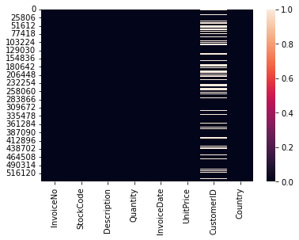

```python
sns.heatmap(retail.isnull())
```

```python
#Fill Null value
CI=retail['CustomerID'].mode()[0]
retail['CustomerID'].replace(np.nan,CI,inplace=True)
retail.isnull().sum()
```

```
InvoiceNo         0
StockCode         0
Description    1454
Quantity          0
InvoiceDate       0
UnitPrice         0
CustomerID        0
Country           0
dtype: int64
```

```python
#Drop rest missing value/
retail=retail.dropna()
retail.isnull().sum()
```

```
InvoiceNo      0
StockCode      0
Description    0
Quantity       0
InvoiceDate    0
UnitPrice      0
CustomerID     0
Country        0
dtype: int64
```

```python
retail.shape
```

```
(540455, 8)
```

```python
#changing the CustomerID to str
retail['CustomerID']=retail['CustomerID'].astype(str)
```

```python
retail.info()
```

```
<class 'pandas.core.frame.DataFrame'>
Int64Index: 540455 entries, 0 to 541908
Data columns (total 8 columns):
 #   Column       Non-Null Count   Dtype
---  ------       --------------   -----
 0   InvoiceNo    540455 non-null  object
 1   StockCode    540455 non-null  object
 2   Description  540455 non-null  object
 3   Quantity     540455 non-null  int64
 4   InvoiceDate  540455 non-null  datetime64[ns]
 5   UnitPrice    540455 non-null  float64
 6   CustomerID   540455 non-null  object
 7   Country      540455 non-null  object
dtypes: datetime64[ns](1), float64(1), int64(1), object(5)
memory usage: 37.1+ MB
```

### Step 3 : Data Preparation

## We are going to analysis the Customers based on below 3 factors:

*R (Recency): Number of days since last purchase

*F (Frequency): Number of tracsactions

*M (Monetary): Total amount of transactions (revenue contributed)

```python
#New attributes:Monetary
retail['Amount']=retail['Quantity']*retail['UnitPrice']
rfm_m=retail.groupby('CustomerID')['Amount'].sum()
rfm_m=rfm_m.reset_index()
rfm_m.head()
```

|  | CustomerID | Amount |
| --- | --- | --- |
| 0 | 12346.0 | 0.00 |
| 1 | 12347.0 | 4310.00 |
| 2 | 12348.0 | 1797.24 |
| 3 | 12349.0 | 1757.55 |
| 4 | 12350.0 | 334.40 |

```python
#New attributes:Frequency:
rfm_f=retail.groupby('CustomerID')['InvoiceNo'].count()
rfm_f=rfm_f.reset_index()
rfm_f.columns=['CustomerID','Frequency']
rfm_f.head()
```

|  | CustomerID | Frequency |
| --- | --- | --- |
| 0 | 12346.0 | 2 |
| 1 | 12347.0 | 182 |
| 2 | 12348.0 | 31 |
| 3 | 12349.0 | 73 |
| 4 | 12350.0 | 17 |

```python
#Merging the two dfs

rfm=pd.merge(rfm_f,rfm_m,on='CustomerID',how='inner')
rfm.head()
```

|  | CustomerID | Frequency | Amount |
| --- | --- | --- | --- |
| 0 | 12346.0 | 2 | 0.00 |
| 1 | 12347.0 | 182 | 4310.00 |
| 2 | 12348.0 | 31 | 1797.24 |
| 3 | 12349.0 | 73 | 1757.55 |
| 4 | 12350.0 | 17 | 334.40 |

```python
#New Attributes: Recency

#covert to datetime to proper datatype
retail['InvoiceDate']=pd.to_datetime(retail['InvoiceDate'],format='%d-%m-%Y %H:%M')
```

```python
# Compute the maximum date to know the last transaction date

max_date=max(retail['InvoiceDate'])
max_date
```

```
Timestamp('2011-12-09 12:50:00')
```

```python
retail.head()
```

|  | InvoiceNo | StockCode | Description | Quantity | InvoiceDate | UnitPrice | CustomerID | Country | Amount |
| --- | --- | --- | --- | --- | --- | --- | --- | --- | --- |
| 0 | 536365 | 85123A | WHITE HANGING HEART T-LIGHT HOLDER | 6 | 2010-12-01 08:26:00 | 2.55 | 17850.0 | United Kingdom | 15.30 |
| 1 | 536365 | 71053 | WHITE METAL LANTERN | 6 | 2010-12-01 08:26:00 | 3.39 | 17850.0 | United Kingdom | 20.34 |
| 2 | 536365 | 84406B | CREAM CUPID HEARTS COAT HANGER | 8 | 2010-12-01 08:26:00 | 2.75 | 17850.0 | United Kingdom | 22.00 |
| 3 | 536365 | 84029G | KNITTED UNION FLAG HOT WATER BOTTLE | 6 | 2010-12-01 08:26:00 | 3.39 | 17850.0 | United Kingdom | 20.34 |
| 4 | 536365 | 84029E | RED WOOLLY HOTTIE WHITE HEART. | 6 | 2010-12-01 08:26:00 | 3.39 | 17850.0 | United Kingdom | 20.34 |

```python
# Compute the difference between max date and transaction date
retail['diff']=max_date-retail['InvoiceDate']
retail.head()
```

|  | InvoiceNo | StockCode | Description | Quantity | InvoiceDate | UnitPrice | CustomerID | Country | Amount | diff |
| --- | --- | --- | --- | --- | --- | --- | --- | --- | --- | --- |
| 0 | 536365 | 85123A | WHITE HANGING HEART T-LIGHT HOLDER | 6 | 2010-12-01 08:26:00 | 2.55 | 17850.0 | United Kingdom | 15.30 | 373 days 04:24:00 |
| 1 | 536365 | 71053 | WHITE METAL LANTERN | 6 | 2010-12-01 08:26:00 | 3.39 | 17850.0 | United Kingdom | 20.34 | 373 days 04:24:00 |
| 2 | 536365 | 84406B | CREAM CUPID HEARTS COAT HANGER | 8 | 2010-12-01 08:26:00 | 2.75 | 17850.0 | United Kingdom | 22.00 | 373 days 04:24:00 |
| 3 | 536365 | 84029G | KNITTED UNION FLAG HOT WATER BOTTLE | 6 | 2010-12-01 08:26:00 | 3.39 | 17850.0 | United Kingdom | 20.34 | 373 days 04:24:00 |
| 4 | 536365 | 84029E | RED WOOLLY HOTTIE WHITE HEART. | 6 | 2010-12-01 08:26:00 | 3.39 | 17850.0 | United Kingdom | 20.34 | 373 days 04:24:00 |

```python
#compute last transaction date to get the recency of customer
rfm_p=retail.groupby('CustomerID')['diff'].min()
rfm_p=rfm_p.reset_index()
rfm_p.head()
```

|  | CustomerID | diff |
| --- | --- | --- |
| 0 | 12346.0 | 325 days 02:33:00 |
| 1 | 12347.0 | 1 days 20:58:00 |
| 2 | 12348.0 | 74 days 23:37:00 |
| 3 | 12349.0 | 18 days 02:59:00 |
| 4 | 12350.0 | 309 days 20:49:00 |

```python
## Extract number of days only

rfm_p['diff']=rfm_p['diff'].dt.days
rfm_p.head()
```

|  | CustomerID | diff |
| --- | --- | --- |
| 0 | 12346.0 | 325 |
| 1 | 12347.0 | 1 |
| 2 | 12348.0 | 74 |
| 3 | 12349.0 | 18 |
| 4 | 12350.0 | 309 |

```python
# Merge tha dataframes to get the final RFM dataframe
rfm=pd.merge(rfm,rfm_p,on='CustomerID',how='inner')
rfm.columns=['CustomerID','Amount','Frequency','Recency']
rfm.head()
```

|  | CustomerID | Amount | Frequency | Recency |
| --- | --- | --- | --- | --- |
| 0 | 12346.0 | 2 | 0.00 | 325 |
| 1 | 12347.0 | 182 | 4310.00 | 1 |
| 2 | 12348.0 | 31 | 1797.24 | 74 |
| 3 | 12349.0 | 73 | 1757.55 | 18 |
| 4 | 12350.0 | 17 | 334.40 | 309 |

### There are 2 types of outliers and we will treat outliers as it can skew our dataset

.Statistical

.Domain specific

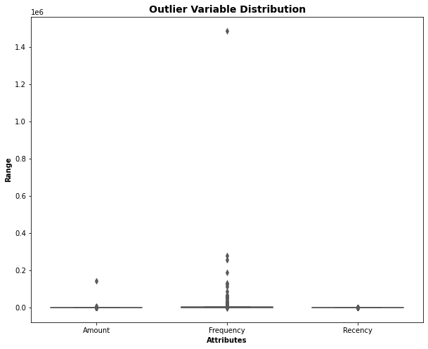

```python
#outlier Analysis  of  Amount Frequency and Recency

attributes=['Amount','Frequency','Recency']
plt.rcParams['figure.figsize']=[10,8]

sns.boxplot(data=rfm[attributes],orient='v',palette='Set2',whis=1.5,saturation=1,width=0.7)
plt.title('Outlier Variable Distribution' ,fontsize=14,fontweight='bold')
plt.ylabel('Range',fontweight='bold')
plt.xlabel('Attributes',fontweight='bold')
```

```python
#Removing (staticalstatices) outlier for Amount

Q1=rfm.Amount.quantile(0.05)
Q3=rfm.Amount.quantile(0.95)

IQR=Q3-Q1
rfm=rfm[(rfm.Amount>=Q1-1.5*IQR)&(rfm.Amount<=Q3+1.5*IQR)]


##Removing (staticalstatices) outlier for Recency

Q1=rfm.Recency.quantile(0.05)
Q3=rfm.Recency.quantile(0.95)


IQR=Q3-Q1

rfm=rfm[(rfm.Recency>=Q1-1.5*IQR)&(rfm.Recency<=Q3+1.5*IQR)]



# Removing (statistical) outliers for Frequency
Q1 = rfm.Frequency.quantile(0.05)
Q3 = rfm.Frequency.quantile(0.95)
IQR = Q3 - Q1
rfm = rfm[(rfm.Frequency >= Q1 - 1.5*IQR) & (rfm.Frequency <= Q3 + 1.5*IQR)]
```

### Rescaling the Attributes

It is extremely important to rescale the variables so that they have a comparable scale.| There are two common ways of rescaling:

*Min-Max scaling

*Standardisation (mean-0, sigma-1)

Here, we will use Standardisation Scaling.

```python
#Rescaling the attributes
rfm_df=rfm[['Amount','Frequency','Recency']]


#Instantiate

scaler=StandardScaler()

#fit_transform

rfm_df_scaled=scaler.fit_transform(rfm_df)
rfm_df_scaled.shape
```

```
(4290, 3)
```

```python
rfm_df_scaled = pd.DataFrame(rfm_df_scaled)
rfm_df_scaled.columns = ['Amount', 'Frequency', 'Recency']
rfm_df_scaled.head()
```

|  | Amount | Frequency | Recency |
| --- | --- | --- | --- |
| 0 | -0.749872 | -0.738835 | 2.300765 |
| 1 | 1.041232 | 1.796627 | -0.906903 |
| 2 | -0.461305 | 0.318435 | -0.184188 |
| 3 | -0.043381 | 0.295086 | -0.738600 |
| 4 | -0.600614 | -0.542116 | 2.142362 |

## Step 4 : Building the Model

### K-Means Clustering

```python
# k-means with some arbitrary k

kmeans = KMeans(n_clusters=4, max_iter=50)
kmeans.fit(rfm_df_scaled)
```

```
KMeans(max_iter=50, n_clusters=4)
```

```python
kmeans.labels_
```

```
array([2, 3, 0, ..., 0, 1, 0])
```

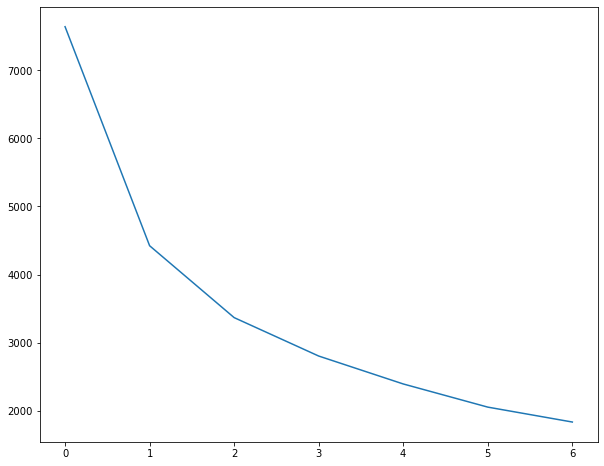

```python
# Elbow-curve/SSD

ssd = []
range_n_clusters = [2, 3, 4, 5, 6, 7, 8]
for num_clusters in range_n_clusters:
    kmeans = KMeans(n_clusters=num_clusters, max_iter=50)
    kmeans.fit(rfm_df_scaled)

    ssd.append(kmeans.inertia_)

# plot the SSDs for each n_clusters
plt.plot(ssd)
```

```python
# Final model with k=3
kmeans = KMeans(n_clusters=3, max_iter=50)
kmeans.fit(rfm_df_scaled)
```

```
KMeans(max_iter=50, n_clusters=3)
```

```python
 kmeans.labels_
```

```
array([1, 2, 0, ..., 0, 2, 0])
```

```python
# assign the label
rfm['Cluster_Id'] = kmeans.labels_
rfm.head()
```

|  | CustomerID | Amount | Frequency | Recency | Cluster_Id |
| --- | --- | --- | --- | --- | --- |
| 0 | 12346.0 | 2 | 0.00 | 325 | 1 |
| 1 | 12347.0 | 182 | 4310.00 | 1 | 2 |
| 2 | 12348.0 | 31 | 1797.24 | 74 | 0 |
| 3 | 12349.0 | 73 | 1757.55 | 18 | 0 |
| 4 | 12350.0 | 17 | 334.40 | 309 | 1 |

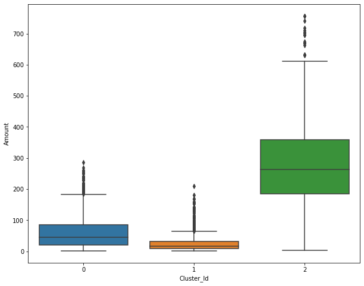

```python
# Box plot to visualize Cluster Id vs Frequency

sns.boxplot(x='Cluster_Id', y='Amount', data=rfm)
```

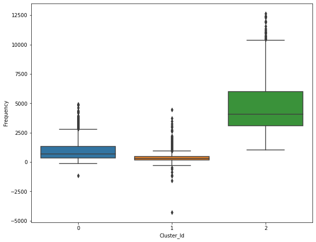

```python
# Box plot to visualize Cluster Id vs Frequency

sns.boxplot(x='Cluster_Id', y='Frequency', data=rfm)
```

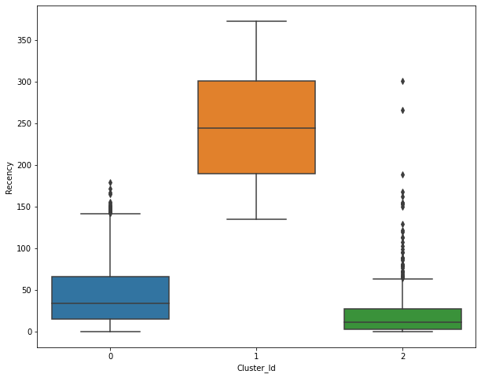

```python
# Box plot to visualize Cluster Id vs Recency

sns.boxplot(x='Cluster_Id', y='Recency', data=rfm)
```

### Step 5 : Final Analysis

### Inference:

K-Means Clustering with 3 Cluster Ids